# Advanced Modelling Final Project

## Binary Classification with Logit and Probit Models

### Motivation:

Logit and probit models are two similar classification models that can be used to predict a binary response variable. In many experiments and observational studies, the main subject of interest is a binary qualitative variable, or a variable that has only two categories. Though linear regression works well on continuous response variables with constant marginal effects, the method struggles when the range of values the response variable can take are only 0 or 1. The logit and probit models seek to remedy the lack of a proper fitting line by fitting a non linear link function to the data to transform the data into a continuous range of values within the restricted range of 0 and 1. These models are types of generalized linear models (GLM’s).

#### Beginning Implementation:

In order to be able to fit a logit or probit model, the data usually has to be transformed. Often, binary categorical data has values such as “yes” and “no”, “agree” and “disagree” or “True” and “False”. Creating dummy variables is a way to assign the two categories either a value of 0 or 1 based on the presence of absence of a qualitative attribute respectively. This dummying of variables not only enables computers to understand the data, it enables the visualization of points on a graph.

Below, the binary variable “vs” from the dataset mtcars represents the car having a v pattern of engine cylinders. When plotted against “hp”, which is the horsepower of the car, and fit with a linear regression least squares line, the graph below is the result.

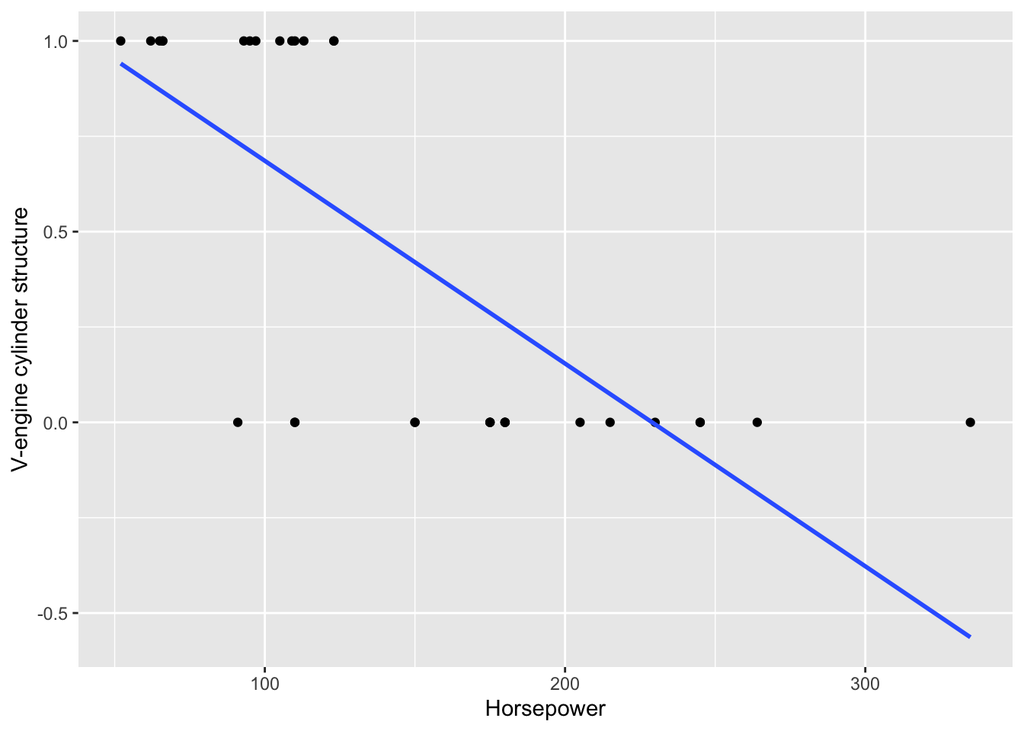

```r
mtcars %>%
  ggplot(aes(x = hp, y = vs)) + geom_point() + geom_smooth(method = 'lm',formula = y ~ x, se = FALSE) + labs(x = "Horsepower", y = "V-engine cylinder structure", Title = 'Linear Regression Line')
```

Fitting a linear line to this data seems to be out of place, as it extends far beyond the values of 0 and 1, which does not make sense in this scenario. When the logit model is fit on this same data, this resulting line looks like an “s” , this is also known as a “sigmoid curve”.

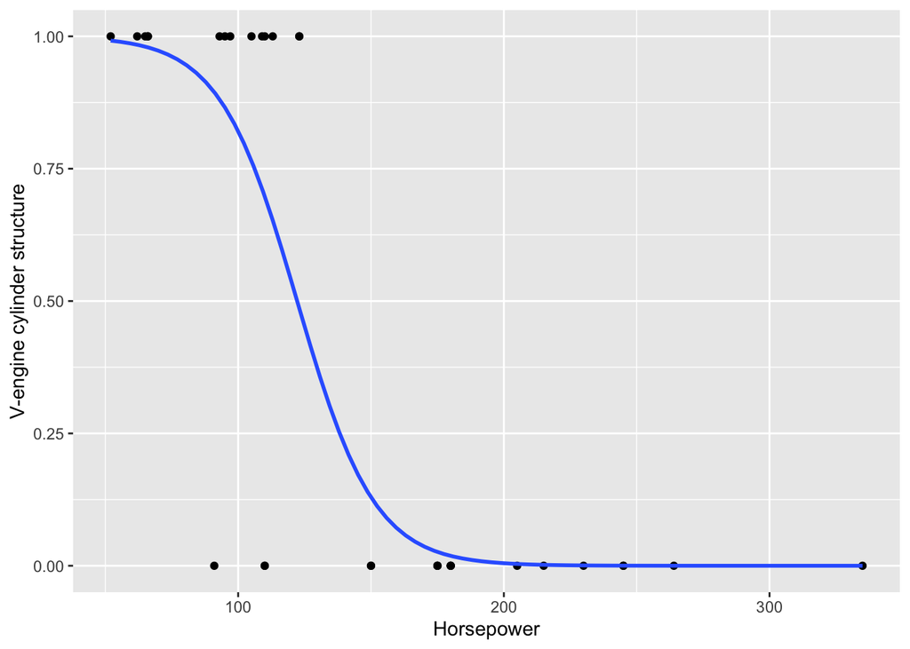

```r
mtcars %>% ggplot(aes(x=hp, y=vs)) +
  geom_point() + stat_smooth(method="glm",  se=FALSE, method.args = list(family=binomial)) + labs(x = "Horsepower", y = "V-engine cylinder structure", Title = 'Logistic Regression Line')
```

### Generalized Linear Models (GLM)

GLM’s are used when the residuals of the response variable are not normally distributed and therefore do not fit under the assumptions of linear regression. Such is the case when categorical data is being fit. GLM’s have the form,

$$f(\mu_{y})= \beta_{0}+\beta_{0}X_1+...\beta_{k}X_k$$

where $f(\mu_{y})$, is a link function. The link function enables the model to fit in a binomial distribution and take a linear form by taking the mean of Y and running it through the function. The logit and probit functions convert the probability of a certain outcome into a continuous value from $-\infty$ to $\infty$ while establishing a linear relationship with the predictor variables. The main differences between logit and probit are the link functions used to make this transformation.

##### Maximum Likelilhood Estimation

The logit and probit models use maximum likelihood estimation to determine the parameter values/coefficients for the model. This is different than the standard least squares method used by linear regression. The parameter values are best estimated such that they maximize the likelihood that the potential outcomes of Y, as described by the model, reproduce the data that were actually observed.

##### The Logit Model (Logistic Classification)

The logistic model uses a link function called the logit link function to transform data from dichotomous values **of** 0 and 1 to continuous values **between** 0 and 1. This enables the model to estimate the probabilities of an event occuring given certain inputs.

$$f(\mu_{y}) = ln(\frac{probability}{1-probability})$$

This log-odds function above is the link function which takes the regression coefficients and logs them, preventing negative values and transforms the data into final values that depict the log-odds of the response occuring. The equation below arises from the cumulative distribution function of the standard normal distribution. As the exponent, the regression equation, approaches positive infinity, the probability of the event occurring reaches 1, and as the exponent approaches negative infinity, the probability converges to 0.

$$p(x) = \frac{e^{\beta_{0}+\beta_{0}X_1+...\beta_{k}X_k}}{1+e^{\beta_{0}+\beta_{0}X_1+...\beta_{k}X_k}}$$

This transformation gives non-linear changes in the value of the response variable for one unit changes in X. This differs from the linear line, as there are constant changes in Y for one unit changes in X. This transformation results in the “s shaped” curve seen in logistic models.

Interpreting the logistic model requires a back transformation of the coefficients. To return the log-odds coefficient into odds terms, the coefficients are entered into the equation below.

$$odds = \frac{1}{1+e^{-(\beta_{0}+\beta_{0}X_1+…\beta_{k}X_k)}}$$

#### The Probit Model

Instead of using linear functions to estimate probability of being in a specific class, probit models employ the inverse normal link function.

$$f(\mu)=\Phi^{-1}(Probability)$$

The inverse normal link function converts the probability of a certain outcome occurring into a z - score. This z-score is then used to calculate the probability of the event occurring. This is possible due to this function following a standard normal distribution, in this case, the z - distribution. In this distribution, every value of Z has an associated probability of being one of two categories. Higher values of Z mean that the event is more likely to occur, as the probability that the measured value will be less than z increases.

When plotted all together, these z scores and their associated probabilities create a sigmodal curve similar to the logistic model, as seen below.

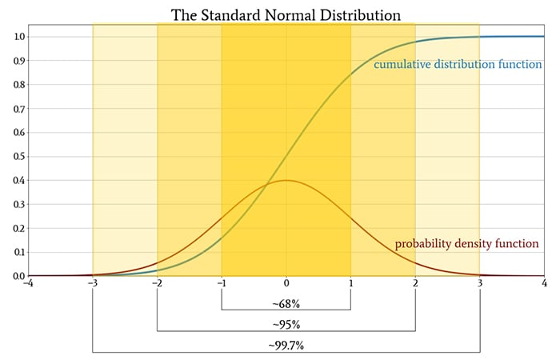

This graphic highlights how the probabilities are normally distributed and within the inverse normal link. In this form with these standardized values, its possible to see the probability density function and 68%/95%/99.7% rule that is known about normal distributions. This rule states that a random value x has a 68% chance of falling within 1 standard deviation away from the mean, a 95% chance of falling within 2 standard deviations of the mean, and a 99.7% chance of falling 3 standard deviations away from the mean.

The probability density function(PDF) gives the probability density of an event occurring, ie how often a certain percentage or range of percentages will occur. The cumulative density function shows that random variable z, the CDF equals the probability that Z is less than or equal to a given z. Where the CDF or probit model = .5, lies the point of equal opportunity. At this point, the probability of being in one of two classes is 50%. Above this z-score is a higher probability of being classified as category 1, and below this point is a lower probability of being classified as category1. If observing the mtcars data, this would mean that a car with about 125 hp would have equal chance of being classified as having a V formation engine or not.

###### Interpretation of Coefficients

When interpreting coefficients from a probit model, it is important to note that the effect is not constant throughout the entire range of X. This means that a 1% increase in X will raise the z-score of Pr(Y=1) by the coefficient of C. So raising x has a constant effect on $f(\mu)$, but does not mean a constant effect on the original, untransformed Y. Graphically, the steeper the line is, the greater a 1 unit increase in X has on the associated Y value. This effect is much more pronounced in the middle of the distribution than in the tails.

##### Which Model to Choose?

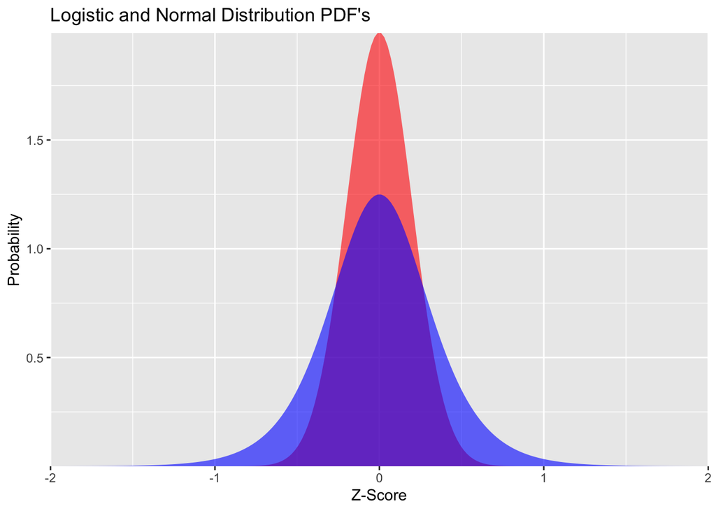

```r
x <- seq(-2,2,length=200) #z scores from -2 to 2
df <- data.frame(
  norm = dnorm(x,mean=0,sd=0.2),
  logistic = dlogis(x,location=0,scale=0.2), x = x
)
 p <- df %>%
  ggplot(aes(x=x)) +
  geom_polygon(aes(y=norm), fill="red", alpha=0.6) +
  geom_polygon(aes(y=logistic), fill="blue", alpha=0.6) +
  scale_x_continuous(expand = c(0, 0)) +
  scale_y_continuous(expand = c(0, 0)) +
 labs(title ="Logistic and Normal Distribution PDF's", x = "Z-Score", y = "Probability" )

print(p)
```

[figure not shown]

If interpretation is the goal, the logit model is a bit easier to understand. Back-transformation can give easy to interpret coefficient estimates. Having the odds of events adjust with a one unit change in X is a simple association to make. To fully understand the probit model, slightly deeper intuition is needed. However in many econometric and political science applications, the probit is the most commonly used.

### Works Cited

Albright, Jeremy. “What Is the Difference between Logit and Probit Models?” Tutorials, 4 Mar. 2019, https://tutorials.methodsconsultants.com/posts/what-is-the-difference-between-logit-and-probit-models/.

Brooks-Bartlett, Jonny. “Probability Concepts Explained: Maximum Likelihood Estimation.” Medium, Towards Data Science, 31 Jan. 2018, https://towardsdatascience.com/probability-concepts-explained-maximum-likelihood-estimation-c7b4342fdbb1.

Grace-Martin, Karen. “Confusing Statistical Term #7: GLM.” The Analysis Factor, 25 Nov. 2020, https://www.theanalysisfactor.com/confusing-statistical-term-7-glm/.

Keim, Robert. “The Cumulative Distribution Function in Normally Distributed Data - Technical Articles.” All About Circuits, 19 Aug. 2020, https://www.allaboutcircuits.com/technical-articles/cumulative-distribution-function-probabilities-normally-distributed-data/.

Kumar, Ajitesh. “Logit vs Probit Models: Differences, Examples.” Data Analytics, 31 Mar. 2022, https://vitalflux.com/logit-vs-probit-models-differences-examples/.

O’Halloran, Sharyn. Lecture 9: Logit/Probit - Columbia University. Columbia University, http://www.columbia.edu/~so33/SusDev/Lecture_9.pdf.